# eda.R

gqueiroz

Thu Sep 4 19:06:29 2014

```r
setwd("/Users/gqueiroz/Dropbox/Rladies/Meetups/Kaggle.Competition/Titanic/")
library('ProjectTemplate')
load.project()
```

```
## Loading project configuration
## Autoloading helper functions
##  Running helper script: helpers.R
## Autoloading cache
## Autoloading data
##  Loading data set: test
##  Loading data set: train
## Munging data
##  Running preprocessing script: 01-A.R
```

```r
train2 <- read.csv("./data/train.csv", header = TRUE, stringsAsFactors = FALSE)
str(train2)
```

```
## 'data.frame':    891 obs. of  12 variables:
##  $ PassengerId: int  1 2 3 4 5 6 7 8 9 10 ...
##  $ Survived   : int  0 1 1 1 0 0 0 0 1 1 ...
##  $ Pclass     : int  3 1 3 1 3 3 1 3 3 2 ...
##  $ Name       : chr  "Braund, Mr. Owen Harris" "Cumings, Mrs. John Bradley (Florence Briggs Thayer)" "Heikkinen, Miss. Laina" "Futrelle, Mrs. Jacques Heath (Lily May Peel)" ...
##  $ Sex        : chr  "male" "female" "female" "female" ...
##  $ Age        : num  22 38 26 35 35 NA 54 2 27 14 ...
##  $ SibSp      : int  1 1 0 1 0 0 0 3 0 1 ...
##  $ Parch      : int  0 0 0 0 0 0 0 1 2 0 ...
##  $ Ticket     : chr  "A/5 21171" "PC 17599" "STON/O2. 3101282" "113803" ...
##  $ Fare       : num  7.25 71.28 7.92 53.1 8.05 ...
##  $ Cabin      : chr  "" "C85" "" "C123" ...
##  $ Embarked   : chr  "S" "C" "S" "S" ...
```

Look at the first 10 rows

```r
head(train, 10)
```

```
##    PassengerId Survived Pclass
## 1            1        0      3
## 2            2        1      1
## 3            3        1      3
## 4            4        1      1
## 5            5        0      3
## 6            6        0      3
## 7            7        0      1
## 8            8        0      3
## 9            9        1      3
## 10          10        1      2
##                                                   Name    Sex Age SibSp
## 1                              Braund, Mr. Owen Harris   male  22     1
## 2  Cumings, Mrs. John Bradley (Florence Briggs Thayer) female  38     1
## 3                               Heikkinen, Miss. Laina female  26     0
```

[output cut: 18 more lines]

Look at the last rows

```r
tail(train)
```

```
##     PassengerId Survived Pclass                                     Name
## 886         886        0      3     Rice, Mrs. William (Margaret Norton)
## 887         887        0      2                    Montvila, Rev. Juozas
## 888         888        1      1             Graham, Miss. Margaret Edith
## 889         889        0      3 Johnston, Miss. Catherine Helen "Carrie"
## 890         890        1      1                    Behr, Mr. Karl Howell
## 891         891        0      3                      Dooley, Mr. Patrick
##        Sex Age SibSp Parch     Ticket  Fare Cabin Embarked
## 886 female  39     0     5     382652 29.12              Q
## 887   male  27     0     0     211536 13.00              S
## 888 female  19     0     0     112053 30.00   B42        S
## 889 female  NA     1     2 W./C. 6607 23.45              S
## 890   male  26     0     0     111369 30.00  C148        C
## 891   male  32     0     0     370376  7.75              Q
```

See the structuture of the data

```r
str(train)
```

```
## 'data.frame':    891 obs. of  12 variables:
##  $ PassengerId: int  1 2 3 4 5 6 7 8 9 10 ...
##  $ Survived   : int  0 1 1 1 0 0 0 0 1 1 ...
##  $ Pclass     : int  3 1 3 1 3 3 1 3 3 2 ...
##  $ Name       : Factor w/ 891 levels "Abbing, Mr. Anthony",..: 109 191 358 277 16 559 520 629 417 581 ...
##  $ Sex        : Factor w/ 2 levels "female","male": 2 1 1 1 2 2 2 2 1 1 ...
##  $ Age        : num  22 38 26 35 35 NA 54 2 27 14 ...
##  $ SibSp      : int  1 1 0 1 0 0 0 3 0 1 ...
##  $ Parch      : int  0 0 0 0 0 0 0 1 2 0 ...
##  $ Ticket     : Factor w/ 681 levels "110152","110413",..: 524 597 670 50 473 276 86 396 345 133 ...
##  $ Fare       : num  7.25 71.28 7.92 53.1 8.05 ...
##  $ Cabin      : Factor w/ 148 levels "","A10","A14",..: 1 83 1 57 1 1 131 1 1 1 ...
##  $ Embarked   : Factor w/ 4 levels "","C","Q","S": 4 2 4 4 4 3 4 4 4 2 ...
```

Variables

```r
names(train)
```

```
##  [1] "PassengerId" "Survived"    "Pclass"      "Name"        "Sex"
##  [6] "Age"         "SibSp"       "Parch"       "Ticket"      "Fare"
## [11] "Cabin"       "Embarked"
```

Summary Stats

```r
summary(train)
```

```
##   PassengerId     Survived         Pclass
##  Min.   :  1   Min.   :0.000   Min.   :1.00
##  1st Qu.:224   1st Qu.:0.000   1st Qu.:2.00
##  Median :446   Median :0.000   Median :3.00
##  Mean   :446   Mean   :0.384   Mean   :2.31
##  3rd Qu.:668   3rd Qu.:1.000   3rd Qu.:3.00
##  Max.   :891   Max.   :1.000   Max.   :3.00
##
##                                     Name         Sex           Age
##  Abbing, Mr. Anthony                  :  1   female:314   Min.   : 0.42
##  Abbott, Mr. Rossmore Edward          :  1   male  :577   1st Qu.:20.12
##  Abbott, Mrs. Stanton (Rosa Hunt)     :  1                Median :28.00
##  Abelson, Mr. Samuel                  :  1                Mean   :29.70
##  Abelson, Mrs. Samuel (Hannah Wizosky):  1                3rd Qu.:38.00
##  Adahl, Mr. Mauritz Nils Martin       :  1                Max.   :80.00
##  (Other)                              :885                NA's   :177
##      SibSp           Parch            Ticket         Fare
##  Min.   :0.000   Min.   :0.000   1601    :  7   Min.   :  0.0
##  1st Qu.:0.000   1st Qu.:0.000   347082  :  7   1st Qu.:  7.9
##  Median :0.000   Median :0.000   CA. 2343:  7   Median : 14.5
##  Mean   :0.523   Mean   :0.382   3101295 :  6   Mean   : 32.2
##  3rd Qu.:1.000   3rd Qu.:0.000   347088  :  6   3rd Qu.: 31.0
##  Max.   :8.000   Max.   :6.000   CA 2144 :  6   Max.   :512.3
##                                  (Other) :852
##          Cabin     Embarked
##             :687    :  2
##  B96 B98    :  4   C:168
##  C23 C25 C27:  4   Q: 77
##  G6         :  4   S:644
##  C22 C26    :  3
##  D          :  3
##  (Other)    :186
```

How may people survived?

```r
table(train$Survived) # 342 passengers survived, while 549 died
```

```
##
##   0   1
## 549 342
```

How about a proportion?

```r
prop.table(table(train$Survived))
```

```
##
##      0      1
## 0.6162 0.3838
```

```r
mean(train$Age, na.rm = TRUE)
```

```
## [1] 29.7
```

```r
dim(subset(x = train, subset = train$Age < 10))
```

```
## [1] 62 12
```

How many men and women?

```r
summary(train$Sex) # Majority of passengers were male.
```

```
## female   male
##    314    577
```

```r
# Now let’s expand the proportion table command we used last time to do a two-way comparison
# on the number of males and females that survived:
table(train$Sex, train$Survived)
```

```
##
##            0   1
##   female  81 233
##   male   468 109
```

```r
prop.table(table(train$Sex, train$Survived), 1)  # row-wise
```

```
##
##               0      1
##   female 0.2580 0.7420
##   male   0.8111 0.1889
```

```r
# Ages?
summary(train$Age)
```

```
##    Min. 1st Qu.  Median    Mean 3rd Qu.    Max.    NA's
##    0.42   20.10   28.00   29.70   38.00   80.00     177
```

```r
table(train$Survived)
```

```
##
##   0   1
## 549 342
```

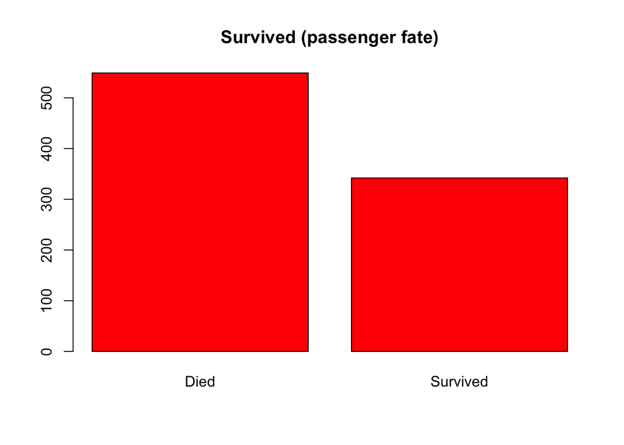

```r
# Making basic visualizations
barplot(table(train$Survived),
        names.arg = c("Died", "Survived"),
        main="Survived (passenger fate)", col="red")
```

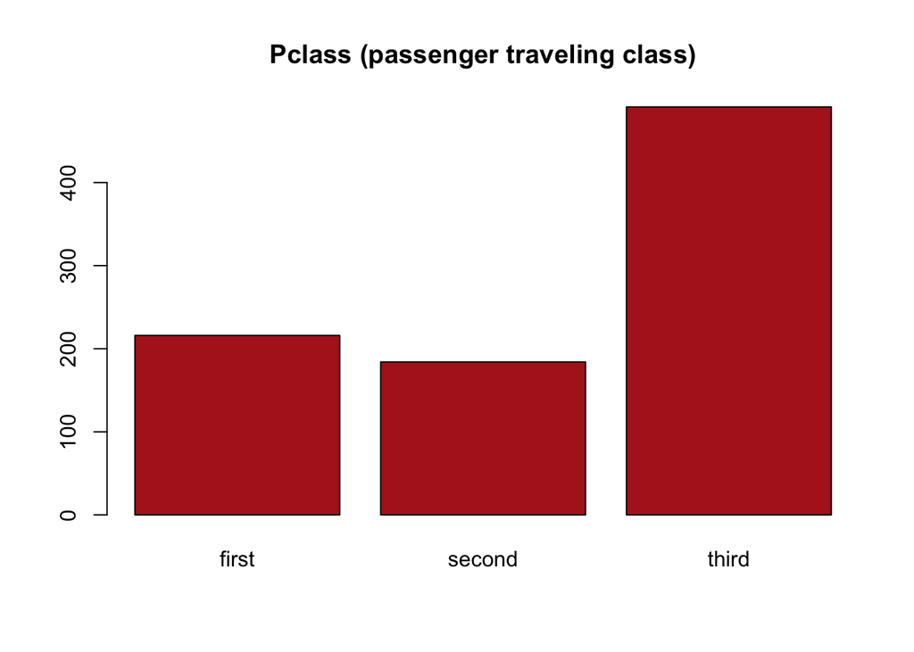

```r
barplot(table(train$Pclass),
        names.arg = c("first", "second", "third"),
        main="Pclass (passenger traveling class)", col="firebrick")
```

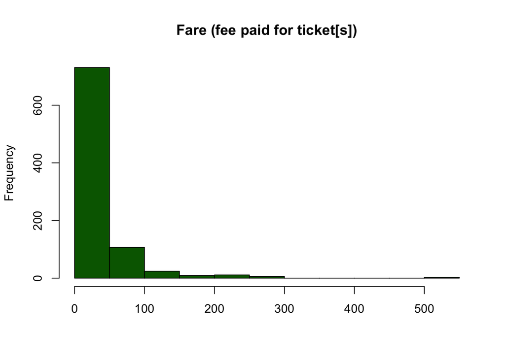

```r
hist(train$Fare, main="Fare (fee paid for ticket[s])",
     xlab = NULL,
     col="darkgreen")
```

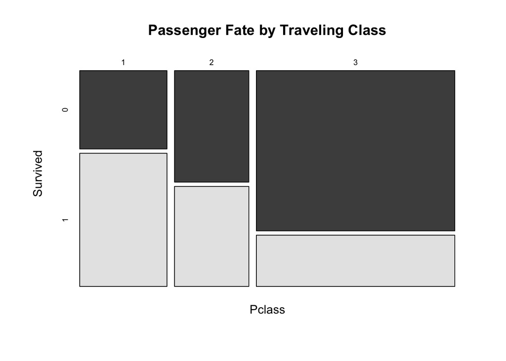

```r
mosaicplot(train$Pclass ~ train$Survived,
           main="Passenger Fate by Traveling Class", shade=FALSE,
           color=TRUE, xlab="Pclass", ylab="Survived")
```

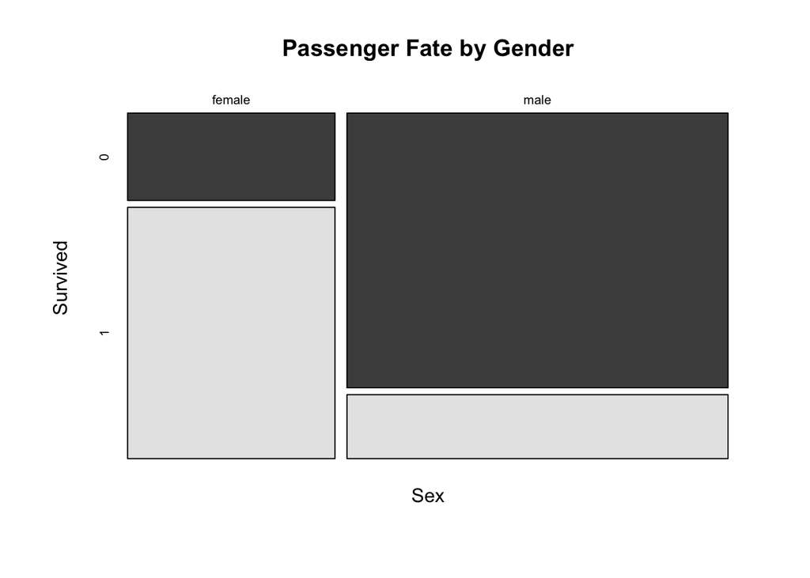

```r
mosaicplot(train$Sex ~ train$Survived,
           main="Passenger Fate by Gender", shade=FALSE,
           color=TRUE,
           xlab="Sex", ylab="Survived")
```

```r
###############################################################################

names(train)
```

```
##  [1] "PassengerId" "Survived"    "Pclass"      "Name"        "Sex"
##  [6] "Age"         "SibSp"       "Parch"       "Ticket"      "Fare"
## [11] "Cabin"       "Embarked"
```

```r
head(train$Name, n=10L)
```

```
##  [1] Braund, Mr. Owen Harris
##  [2] Cumings, Mrs. John Bradley (Florence Briggs Thayer)
##  [3] Heikkinen, Miss. Laina
##  [4] Futrelle, Mrs. Jacques Heath (Lily May Peel)
##  [5] Allen, Mr. William Henry
##  [6] Moran, Mr. James
##  [7] McCarthy, Mr. Timothy J
##  [8] Palsson, Master. Gosta Leonard
##  [9] Johnson, Mrs. Oscar W (Elisabeth Vilhelmina Berg)
## [10] Nasser, Mrs. Nicholas (Adele Achem)
## 891 Levels: Abbing, Mr. Anthony ... Zimmerman, Mr. Leo
```

Cleaning the TRAIN Data

```r
# http://statsguys.wordpress.com/2014/01/11/data-analytics-for-beginners-pt-2/
```

Removing Variables Not Used for the Model Remove the variables: PassengerID, Ticket, Fare, Cabin, and Embarked

```r
train <- train[-c(1,9:12)]
head(train)
```

```
##   Survived Pclass                                                Name
## 1        0      3                             Braund, Mr. Owen Harris
## 2        1      1 Cumings, Mrs. John Bradley (Florence Briggs Thayer)
## 3        1      3                              Heikkinen, Miss. Laina
## 4        1      1        Futrelle, Mrs. Jacques Heath (Lily May Peel)
## 5        0      3                            Allen, Mr. William Henry
## 6        0      3                                    Moran, Mr. James
##      Sex Age SibSp Parch
## 1   male  22     1     0
## 2 female  38     1     0
## 3 female  26     0     0
## 4 female  35     1     0
## 5   male  35     0     0
## 6   male  NA     0     0
```

```r
str(train)
```

```
## 'data.frame':    891 obs. of  7 variables:
##  $ Survived: int  0 1 1 1 0 0 0 0 1 1 ...
##  $ Pclass  : int  3 1 3 1 3 3 1 3 3 2 ...
##  $ Name    : Factor w/ 891 levels "Abbing, Mr. Anthony",..: 109 191 358 277 16 559 520 629 417 581 ...
##  $ Sex     : Factor w/ 2 levels "female","male": 2 1 1 1 2 2 2 2 1 1 ...
##  $ Age     : num  22 38 26 35 35 NA 54 2 27 14 ...
##  $ SibSp   : int  1 1 0 1 0 0 0 3 0 1 ...
##  $ Parch   : int  0 0 0 0 0 0 0 1 2 0 ...
```

Replacing Gender variable (Male/Female) with a Dummy Variable (0/1)

```r
table(train$Sex)
```

```
##
## female   male
##    314    577
```

```r
train$Sex = gsub("female", 1, train$Sex)
train$Sex = gsub("^male", 0, train$Sex)
table(train$Sex)
```

```
##
##   0   1
## 577 314
```

```r
#0   1
#577 314
```

Making Inferences on Missing Age Values Cause age entries could be an important variable we try inferencing them based on a relationship between title and age; we’re essentially assuming that Mrs.X will older than Ms.X. Moreover, we’re (naively) assuming that people with the same titles are closer together in age. So first, we put the index of people with the specified surname into a list for further processing. In R we use #’ the grep() function which will return a vector of row numbers which have a specified surname.

```r
# First change Name to be character
train$Name <- as.character(train$Name)

master_vector = grep("Master.",train$Name, fixed=TRUE)
print(master_vector)
```

```
##  [1]   8  17  51  60  64  66  79 126 160 165 166 172 177 183 184 194 262
## [18] 279 306 341 349 387 408 446 481 490 550 710 752 756 788 789 803 804
## [35] 820 825 828 832 851 870
```

```r
head(train, 20)
```

```
##    Survived Pclass                                                    Name
## 1         0      3                                 Braund, Mr. Owen Harris
## 2         1      1     Cumings, Mrs. John Bradley (Florence Briggs Thayer)
## 3         1      3                                  Heikkinen, Miss. Laina
## 4         1      1            Futrelle, Mrs. Jacques Heath (Lily May Peel)
## 5         0      3                                Allen, Mr. William Henry
## 6         0      3                                        Moran, Mr. James
## 7         0      1                                 McCarthy, Mr. Timothy J
## 8         0      3                          Palsson, Master. Gosta Leonard
## 9         1      3       Johnson, Mrs. Oscar W (Elisabeth Vilhelmina Berg)
## 10        1      2                     Nasser, Mrs. Nicholas (Adele Achem)
## 11        1      3                         Sandstrom, Miss. Marguerite Rut
## 12        1      1                                Bonnell, Miss. Elizabeth
## 13        0      3                          Saundercock, Mr. William Henry
## 14        0      3                             Andersson, Mr. Anders Johan
```

[output cut: 27 more lines]

```r
miss_vector = grep("Miss.", train$Name, fixed=TRUE)
mrs_vector = grep("Mrs.", train$Name, fixed=TRUE)
mr_vector = grep("Mr.", train$Name, fixed=TRUE)
dr_vector = grep("Dr.", train$Name, fixed=TRUE)
```

You might have noticed that there are other less frequent titles such as Reverend or Colonel which we are ignoring for now.

```r
for(i in master_vector) {
    train$Name[i] = "Master"
}

for(i in miss_vector) {
    train$Name[i] = "Miss"
}

for(i in mrs_vector) {
    train$Name[i] = "Mrs"
}

for(i in mr_vector) {
    train$Name[i] = "Mr"
}

for(i in dr_vector) {
    train$Name[i] = "Dr"
}
```

Making Inference on Missing Age Values: Inputting Title-group averages

```r
# We replace the missing ages with their respective title-group average. This means that if we have a missing age # entry for a man named Mr. Bond, # we substitute his age for the average age for all passenger with the title Mr. # Similarly for Master, Miss, Mrs, and Dr.
# We then write a for loop that goes through the entire Train data set and # checks if the age value is missing.
# If it is, we assign it according to the surname of the observation. This code snippet is a bit complicated; you can just copy and paste for now if # you’re not confident about understanding it!


master_age = round(mean(train$Age[train$Name == "Master"], na.rm = TRUE), digits = 2)
miss_age = round(mean(train$Age[train$Name == "Miss"], na.rm = TRUE), digits =2)
mrs_age = round(mean(train$Age[train$Name == "Mrs"], na.rm = TRUE), digits = 2)
mr_age = round(mean(train$Age[train$Name == "Mr"], na.rm = TRUE), digits = 2)
dr_age = round(mean(train$Age[train$Name == "Dr"], na.rm = TRUE), digits = 2)
for (i in 1:nrow(train)) {
    if (is.na(train[i,5])) {
        if (train$Name[i] == "Master") {
            train$Age[i] = master_age
        } else if (train$Name[i] == "Miss") {
            train$Age[i] = miss_age
        } else if (train$Name[i] == "Mrs") {
            train$Age[i] = mrs_age
        } else if (train$Name[i] == "Mr") {
            train$Age[i] = mr_age
        } else if (train$Name[i] == "Dr") {
            train$Age[i] = dr_age
        } else {
            print("Uncaught Title")
        }
    }
}
```

Creating New Variables to Strengthen Our Model VARIABLE 1: CHILD.

```r
# This additional variable choice stems from the fact that we suspect that being a child might affect the survival rate of a passenger.
```

We start by creating a child variable. This is done by appending an empty column to the dataset, titled “Child”. We then populate the column with value “1”, if the passenger is under the age of 12, and “2” otherwie.

```r
train$Child <- c()
head(train)
```

```
##   Survived Pclass Name Sex   Age SibSp Parch
## 1        0      3   Mr   0 22.00     1     0
## 2        1      1  Mrs   1 38.00     1     0
## 3        1      3 Miss   1 26.00     0     0
## 4        1      1  Mrs   1 35.00     1     0
## 5        0      3   Mr   0 35.00     0     0
## 6        0      3   Mr   0 32.37     0     0
```

```r
for (i in 1:nrow(train)) {
    if (train$Age[i] <= 12) {
        train$Child[i] = 1
    } else {
        train$Child[i] = 2
    }
}
```

VARIABLE 2: FAMILY

```r
# This variable is meant to represent the family size of each passenger by adding the number of Siblings/Spouses and Parents/Children (we add 1 so # # minimum becomes 1).
# We’re guessing that larger families are less likely to survive, or perhaps it is the other way around. The beautiful part is that it doesn’t matter!
# The model we build will optimize for the problem. All we’re indicating is that there might be a relationship between family size and survival rate.

train["Family"] = NA
head(train)
```

```
##   Survived Pclass Name Sex   Age SibSp Parch Child Family
## 1        0      3   Mr   0 22.00     1     0     2     NA
## 2        1      1  Mrs   1 38.00     1     0     2     NA
## 3        1      3 Miss   1 26.00     0     0     2     NA
## 4        1      1  Mrs   1 35.00     1     0     2     NA
## 5        0      3   Mr   0 35.00     0     0     2     NA
## 6        0      3   Mr   0 32.37     0     0     2     NA
```

```r
for(i in 1:nrow(train)) {
    x = train$SibSp[i]
    y = train$Parch[i]
    train$Family[i] = x + y + 1
}
```

VARIABLE 3: MOTHER

```r
#We add another variable indicating whether the passenger is a mother.
#This is done by going through the passengers and checking to see if the title is Mrs and if the number of kids is greater than 0. This also includes any titles with Mrs and if the number of parents is greater than 0
train["Mother"] <- NA
for(i in 1:nrow(train)) {
    if(train$Name[i] == "Mrs" & train$Parch[i] > 0) {
        train$Mother[i] = 1
    } else {
        train$Mother[i] = 2
    }
}
head(train)
```

```
##   Survived Pclass Name Sex   Age SibSp Parch Child Family Mother
## 1        0      3   Mr   0 22.00     1     0     2      2      2
## 2        1      1  Mrs   1 38.00     1     0     2      2      2
## 3        1      3 Miss   1 26.00     0     0     2      1      2
## 4        1      1  Mrs   1 35.00     1     0     2      2      2
## 5        0      3   Mr   0 35.00     0     0     2      1      2
## 6        0      3   Mr   0 32.37     0     0     2      1      2
```

```r
### MOVE TO ANALYSIS
# Skipped the step: cleaning the test data (I'll do it later)
```

Training a Model